# Wprowadzenie

Projekt dotyczy przygotowania danych do analizy - wyczyszczenie, uzupełnienie braków i zidentyfikoanie wartości odstających. Same dane opisują treningi osób w różnym wielku (Age) i róznym stopniu zaawansowania (Experience_Level).

Nie stawiamy konkretnego pytania na które będziemy szukać odpowiedzi - celem jest przygotowanie danych do analizy oraz ich opis (nie zaś sama analiza).

```python
import pandas as pd
import numpy as np
import missingno as msno
from skimpy import skim
```

```python
# Projekt
gym_org = pd.read_csv('./Data/silownia_new.csv')
gym = gym_org.copy() # Let's create a copy of the original data to work on it and keep the original one as a reference
#gym.info()
#print(gym.isna().any())
#msno.matrix(gym)  # It's abe to create it but... it's so unreadable
skim(gym) #This rocks! Can replace all previous calls (info(), isna().any() and even msno.matrix )
```

```
╭──────────────────────────────────────────────── skimpy summary ─────────────────────────────────────────────────╮
│          Data Summary                Data Types                                                                 │
│ ┏━━━━━━━━━━━━━━━━━━━┳━━━━━━━━┓ ┏━━━━━━━━━━━━━┳━━━━━━━┓                                                          │
│ ┃ Dataframe         ┃ Values ┃ ┃ Column Type ┃ Count ┃                                                          │
│ ┡━━━━━━━━━━━━━━━━━━━╇━━━━━━━━┩ ┡━━━━━━━━━━━━━╇━━━━━━━┩                                                          │
│ │ Number of rows    │ 973    │ │ float64     │ 7     │                                                          │
│ │ Number of columns │ 15     │ │ int64       │ 6     │                                                          │
│ └───────────────────┴────────┘ │ string      │ 2     │                                                          │
│                                └─────────────┴───────┘                                                          │
│                                                     number                                                      │
│ ┏━━━━━━━━━━━━━━━━━━┳━━━━━┳━━━━━━━━━━━━━━━━━┳━━━━━━━┳━━━━━━━━┳━━━━━━━┳━━━━━━━┳━━━━━━━┳━━━━━━━┳━━━━━━━┳━━━━━━━━┓  │
│ ┃ column           ┃ NA  ┃ NA %            ┃ mean  ┃ sd     ┃ p0    ┃ p25   ┃ p50   ┃ p75   ┃ p100  ┃ hist   ┃  │
│ ┡━━━━━━━━━━━━━━━━━━╇━━━━━╇━━━━━━━━━━━━━━━━━╇━━━━━━━╇━━━━━━━━╇━━━━━━━╇━━━━━━━╇━━━━━━━╇━━━━━━━╇━━━━━━━╇━━━━━━━━┩  │
│ │       Age        │ 100 │ 10.277492291880 │ 38.63 │  12.27 │    18 │    28 │    39 │    50 │    59 │ █▇▆█▇▇ │  │
│ │                  │     │             781 │       │        │       │       │       │       │       │        │  │
│ │   Weight (kg)    │   0 │               0 │ 73.85 │  21.21 │    40 │  58.1 │    70 │    86 │ 129.9 │ ▄█▆▃▂▂ │  │
│ │    Height (m)    │   0 │               0 │ 1.723 │ 0.1277 │   1.5 │  1.62 │  1.71 │   1.8 │     2 │ ▅█▇▇▄▄ │  │
│ │     Max_BPM      │   0 │               0 │ 179.9 │  11.53 │   160 │   170 │   180 │   190 │   199 │ ▇▇█▇██ │  │
│ │     Avg_BPM      │   0 │               0 │ 143.8 │  14.35 │   120 │   131 │   143 │   156 │   169 │ ██▇▆▇▇ │  │
│ │   Resting_BPM    │   0 │               0 │ 62.22 │  7.327 │    50 │    56 │    62 │    68 │    74 │ ▆▅▆▆▇█ │  │
│ │ Session_Duration │   0 │               0 │ 1.256 │  0.343 │   0.5 │  1.04 │  1.26 │  1.46 │     2 │ ▂▃▇█▂▃ │  │
│ │     (hours)      │     │                 │       │        │       │       │       │       │       │        │  │
│ │ Calories_Burned  │   0 │               0 │ 905.4 │  272.6 │   303 │   720 │   893 │  1076 │  1783 │ ▂▆█▄▂  │  │
│ │  Fat_Percentage  │   0 │               0 │ 24.98 │  6.259 │    10 │  21.3 │  26.2 │  29.3 │    35 │ ▂▂▄▆█▅ │  │
│ │   Water_Intake   │   0 │               0 │ 2.627 │ 0.6002 │   1.5 │   2.2 │   2.6 │   3.1 │   3.7 │ ▄▆▅█▃▇ │  │
│ │     (liters)     │     │                 │       │        │       │       │       │       │       │        │  │
│ │ Workout_Frequenc │   0 │               0 │ 3.322 │  0.913 │     2 │     3 │     3 │     4 │     5 │ ▄ █ ▇▂ │  │
│ │  y (days/week)   │     │                 │       │        │       │       │       │       │       │        │  │
│ │ Experience_Level │   0 │               0 │  1.81 │ 0.7397 │     1 │     1 │     2 │     2 │     3 │ ▇  █ ▄ │  │
│ │       BMI        │ 150 │ 15.416238437821 │ 24.82 │    6.6 │ 12.32 │ 20.11 │ 23.94 │ 28.45 │ 47.72 │ ▄█▇▃▁▁ │  │
│ │                  │     │             171 │       │        │       │       │       │       │       │        │  │
│ └──────────────────┴─────┴─────────────────┴───────┴────────┴───────┴───────┴───────┴───────┴───────┴────────┘  │
│                                                     string                                                      │
│ ┏━━━━━━━━━━━━┳━━━━━┳━━━━━━━━━━━━┳━━━━━━━━━━┳━━━━━━━━━━┳━━━━━━━━┳━━━━━━┳━━━━━━━━━━━━┳━━━━━━━━━━━━┳━━━━━━━━━━━━┓  │
│ ┃            ┃     ┃            ┃          ┃          ┃        ┃      ┃ chars per  ┃ words per  ┃ total      ┃  │
│ ┃ column     ┃ NA  ┃ NA %       ┃ shortest ┃ longest  ┃ min    ┃ max  ┃ row        ┃ row        ┃ words      ┃  │
│ ┡━━━━━━━━━━━━╇━━━━━╇━━━━━━━━━━━━╇━━━━━━━━━━╇━━━━━━━━━━╇━━━━━━━━╇━━━━━━╇━━━━━━━━━━━━╇━━━━━━━━━━━━╇━━━━━━━━━━━━┩  │
│ │   Gender   │   0 │          0 │   Male   │  Female  │ Female │ Male │       4.95 │          1 │        973 │  │
│ │ Workout_Ty │ 150 │ 15.4162384 │   Yoga   │ Strength │ Cardio │ Yoga │        5.6 │       0.85 │        823 │  │
│ │     pe     │     │   37821171 │          │          │        │      │            │            │            │  │
│ └────────────┴─────┴────────────┴──────────┴──────────┴────────┴──────┴────────────┴────────────┴────────────┘  │
╰────────────────────────────────────────────────────── End ──────────────────────────────────────────────────────╯
```

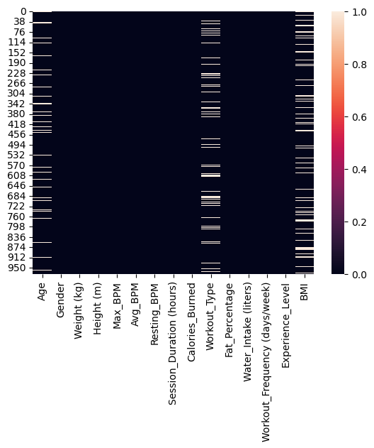

```python
#Let's see the lacks distribution
import seaborn as sns
sns.heatmap(gym.isna());
```

Braki występuja w: Age (100), Workout_Type (150) i BMI (150). Wydają się być rozłożone losowo.

# Czyszczenie i porządkowanie danych

## Encodowanie wartości kategorycznych

```python
#Quick replace Gender: string to int
gender_map = {'Male': 1, 'Female': 0}
gym['Gender'] = gym['Gender'].map(gender_map)
```

```python
#Quick replace Workout type: string to int
workout_type_map = {'HIIT':0, 'Strength':1, 'Cardio':2, 'Yoga':3}
gym['Workout_Type'] = gym['Workout_Type'].map(workout_type_map)
```

## Analiza BMI

BMI możemy policzyć, wg. wzoru. $BMI = \frac{masa\ (kg)}{wzrost^2\ (m)}$ Nie musimy używać specjalnych narzędzi do tej cechy.

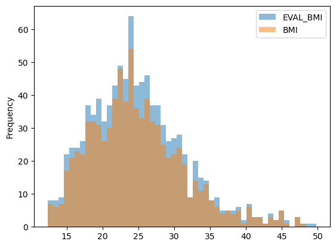

```python
#BMI = Weight / Height**2
#Weight and Height doesn't lack values so we can just evaluate them

gym_bmi = gym.copy()
gym_bmi['EVAL_BMI'] = gym_bmi['Weight (kg)'] / (gym_bmi['Height (m)'] ** 2)

non_nan_bmi = gym_bmi.loc[gym_bmi['BMI'] != np.nan]

gym_bmi['EVAL_BMI_diff'] = (gym_bmi['EVAL_BMI'] - gym_bmi['BMI'])
gym_bmi[['EVAL_BMI', 'BMI']].plot.hist(bins=50, alpha=0.5)
```

Wykres pokazuje, że wyliczone wartości (EVAL_BMI) nie pokrywaja się całkowicie z wartością podaną w danych (BMI). Oryginalne wartości zostawiamy, brakujace wypełniamy.

```python
gym['BMI'] = gym['BMI'].fillna(gym['Weight (kg)'] / (gym['Height (m)'] ** 2))
```

## Analiza Workout Type

Heat mapa z macierzy korelacji - powinna pokazać czy istnieje prosta relacja do innych zmiennych.

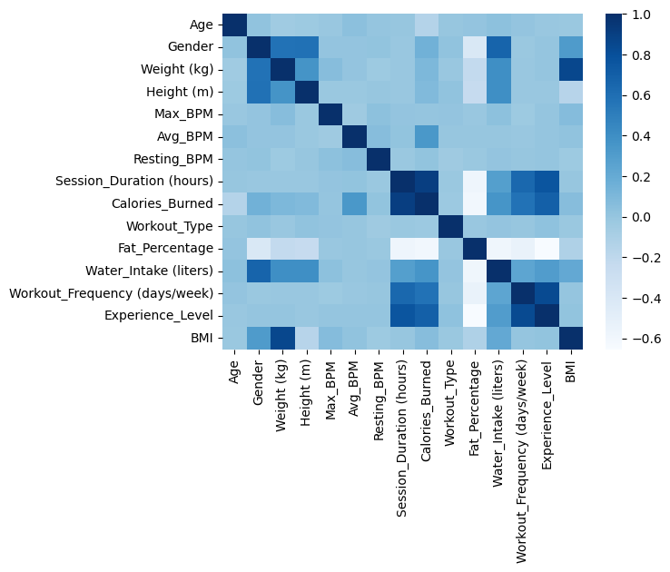

```python
sns.heatmap(gym.select_dtypes(include=np.number).corr(), cmap="Blues")
```

Korelacja Workout_Type do innych zmiennych praktycznie nie istnieje, nie ma się na czym oprzeć. Nie da się wyznaczyć grup osób, które uprawiaja pewien specyficzny typ treningu. Nie jest to też powiązane z wiekiem, ani z doświadczeniem. Nie udaje się też wyznaczyć współczynników, które dobrze byłyby powiązane z typem treningu.

### Teza

Pewien typ treningu spala wiecej kalorii. Można więc wyznaczyć wskaźnik $Burn\ Rate = \frac{Calories\ Burned}{Session\ Duration}$ , który będzie charakteryzował typ treningu.

#### Długość treningu do spalonych kalorii - czy istnieją wyraźne grupy?

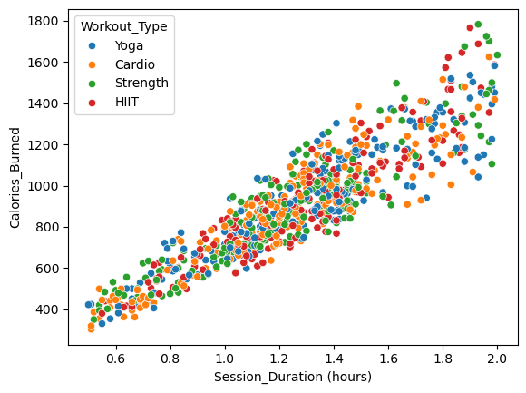

```python
sns.scatterplot(x='Session_Duration (hours)', y='Calories_Burned', hue=gym['Workout_Type'].map(reverse_map), data=gym);
```

Na powyższym wykresie nie widać konkretnych grup. Sprawdźmy jednak czy histogram pokarze coś wiecej.

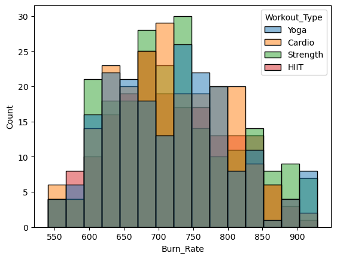

```python
gym['Burn_Rate'] = gym['Calories_Burned'] / gym['Session_Duration (hours)']
gym['BPM_Delta'] = gym['Max_BPM'] - gym['Resting_BPM']
reverse_map = {v: k for k, v in workout_type_map.items()}
sns.histplot(x='Burn_Rate', hue=gym['Workout_Type'].map(reverse_map), data=gym);
```

Znów widać, że rozrzut jest po całej skali. Wniosek: Burn_Rate nie identyfikuje jednoznacznie typu treningu. Długi trening spala dużo kalorii bez względu na typ treningu

### Wniosek

Wydaje się, że Workout_Type nie ma za znaczenia jeśli chodzi o ilosć spalonych kalorii.

Zostawimy zamienione Workout_Type na liczby, KNN wypełni je wynajdując inne potencjalne powiazania.

## Imputacja z użyciem KNN

```python
from sklearn.metrics import mean_squared_error
from sklearn.impute import KNNImputer

import numpy as np
import pandas as pd
import matplotlib.pyplot as plt
import warnings
warnings.filterwarnings('ignore')

numeric_cols = gym.select_dtypes(include=np.number).columns
gym_numeric = gym.copy()[numeric_cols]

original_age = gym_numeric['Age'].copy()
missing_mask_age = original_age.isna()
ground_truth_age = original_age.fillna(original_age.median())
```

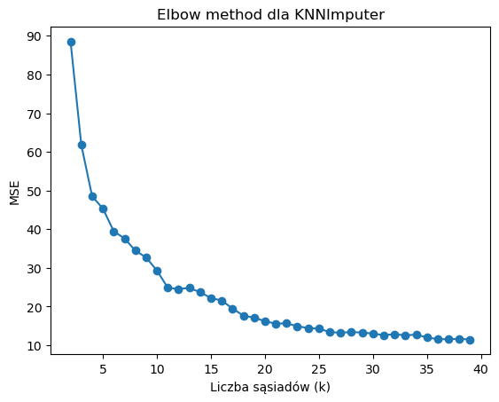

```python
errors = []
neighbors = range(2, 40)

for k in neighbors:
    imputer = KNNImputer(n_neighbors=k)
    imputed = imputer.fit_transform(gym_numeric)
    imputed_df = pd.DataFrame(imputed, columns=numeric_cols, index=gym_numeric.index)

    if missing_mask_age.any():
        imputed_age_at_missing = imputed_df.loc[missing_mask_age, 'Age']
        ground_truth_at_missing = ground_truth_age.loc[missing_mask_age]
        mse = mean_squared_error(ground_truth_at_missing, imputed_age_at_missing)
        errors.append(mse)
    else:
        errors.append(0)

plt.plot(neighbors, errors, marker='o')
plt.xlabel('Liczba sąsiadów (k)')
plt.ylabel('MSE')
plt.title('Elbow method dla KNNImputer')
plt.show()
```

Dla wieku (Age) gdieś między 7 a 15 następuje przegięcie - mamy mało danych, możemy wyrać coś ponad górną wartość i będzie się to szybko liczyć.

```python
imputer = KNNImputer(n_neighbors=20)
imputed = imputer.fit_transform(gym_numeric)
imputed_df = pd.DataFrame(imputed, columns=numeric_cols, index=gym_numeric.index)
```

```python
#Finally replace the org values with imputed
gym['Age'] = imputed_df['Age']
#gym['Workout_Type'] = imputed_df['Workout_Type']
```

```python
import xgboost as xgb
from sklearn.preprocessing import StandardScaler
from sklearn.model_selection import train_test_split
from sklearn.metrics import classification_report
from sklearn.metrics import confusion_matrix, accuracy_score
from sklearn.model_selection import GridSearchCV
from sklearn.svm import SVC
```

```python
def svc_model(X_train, X_test, y_train, y_test):
    # Define the parameter grid
    param_grid = {'C': [0.1, 1, 10, 100],
                  'gamma': [1, 0.1, 0.01, 0.001],
                  'kernel': ['rbf', 'linear', 'poly', 'sigmoid']}

    # Initialize a SVM classifier
    svm_classifier = SVC()

    # Perform grid search for hyperparameter tuning
    grid_search = GridSearchCV(svm_classifier, param_grid, cv=5)
    grid_search.fit(X_train, y_train.values.ravel())

    # Print the best hyperparameters
    print("SVC best Parameters:", grid_search.best_params_)

    # Evaluate the model with the best hyperparameters
    best_model = grid_search.best_estimator_
    y_pred = best_model.predict(X_test)

    accuracy = accuracy_score(y_test.values.ravel(), y_pred)
    return best_model, accuracy, y_pred


def xgbclassifier_model(X_train, X_test, y_train, y_test):
    params = {
        "n_estimators": 2,
        "max_depth": 3,
    }
    xgboost_model = xgb.XGBClassifier(params)
    xgboost_model.fit(X_train, y_train)

    y_pred = xgboost_model.predict(X_test)

    xgb_score = accuracy_score(y_test, y_pred)
    return xgboost_model, xgb_score, y_pred
```

```python
df = gym.copy().dropna().drop_duplicates()

target_names = ['Workout_Type']
feature_names =  [c for c in df.columns if c not in target_names]

#print(f'Feature names: {feature_names}, Target names: {target_names}')
#[print(f'Workout_Type correlation with {x}\n', df[['Workout_Type', x]].corr(method='spearman')) for x in feature_names]

X, y = df[feature_names], df[target_names]


X, y = df[feature_names], df[target_names]
X_train, X_test, y_train, y_test = train_test_split(X, y,
                                                    test_size=0.2,
                                                    random_state=42
                                                    )

# StandardScaler
ss = StandardScaler()
X_train = ss.fit_transform(X_train)
X_test = ss.transform(X_test)

_xgboost_model, xgb_score, y_pred_xgb = xgbclassifier_model(X_train, X_test, y_train, y_test)
_svc_model, svc_score, y_pred_svc = svc_model(X_train, X_test, y_train, y_test)


print(f'XGB accuracy score: {xgb_score * 100}%')
print(f'\t Confusion Matrix(XGB):\n', confusion_matrix(y_test, y_pred_xgb))
print(f'\t Classification report (XGB):\n\n', classification_report(y_test, y_pred_xgb))



print(f'SVC accuracy score: {svc_score * 100}%')
print(f'\t Confusion Matrix (SVC):\n', confusion_matrix(y_test, y_pred_svc))
print(f'\t Classification report (SVC):\n\n', classification_report(y_test, y_pred_svc))
```

```
SVC best Parameters: {'C': 1, 'gamma': 0.01, 'kernel': 'sigmoid'}
XGB accuracy score: 27.878787878787882%
	 Confusion Matrix(XGB):
 [[ 7 11  8  9]
 [ 8  9 15 20]
 [ 5 13 19 12]
 [ 6  3  9 11]]
	 Classification report (XGB):

               precision    recall  f1-score   support

         0.0       0.27      0.20      0.23        35
         1.0       0.25      0.17      0.20        52
         2.0       0.37      0.39      0.38        49
         3.0       0.21      0.38      0.27        29

    accuracy                           0.28       165
   macro avg       0.28      0.29      0.27       165
weighted avg       0.28      0.28      0.27       165

SVC accuracy score: 26.666666666666668%
	 Confusion Matrix (SVC):
 [[ 0 12 17  6]
 [ 0 18 26  8]
 [ 0 20 19 10]
 [ 0  6 16  7]]
	 Classification report (SVC):

               precision    recall  f1-score   support

         0.0       0.00      0.00      0.00        35
         1.0       0.32      0.35      0.33        52
         2.0       0.24      0.39      0.30        49
         3.0       0.23      0.24      0.23        29

    accuracy                           0.27       165
   macro avg       0.20      0.24      0.22       165
weighted avg       0.21      0.27      0.23       165
```

# Epic failure - próba predykcji WorkoutType za pomocą XGB oraz SVC

Obydwa modele (nie były zbytnio tuningowane, ale na sam start spodziewałem się lepszych rezultatów).

XGB accuracy score: 27.878787878787882% SVC accuracy score: 26.666666666666668%

Na koniec odwracamy na powrót wartości zmiennej kategorycznej

```python
reverse_map = {v: k for k, v in workout_type_map.items()}
gym['Workout_Type'] = imputed_df['Workout_Type'].round().astype(int).map(reverse_map)
```

## Podsumowanie wyników

### Porównanie średnich

```python
print("Age: Wartość oryginalna", gym_org['Age'].mean().round(2), " wartość po imputacji: ", gym['Age'].mean().round(2))
print("BMI: Wartość oryginalna", gym_org['BMI'].mean().round(2), " wartość po imputacji: ", gym['BMI'].mean().round(2))
```

```
Age: Wartość oryginalna 38.63  wartość po imputacji:  38.58
BMI: Wartość oryginalna 24.82  wartość po imputacji:  24.91
```

### Workout type względem wieku - dane bez imputacji

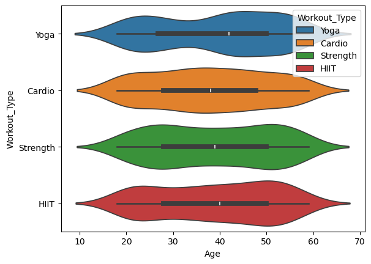

```python
sns.violinplot(y='Workout_Type', x='Age', data=gym_org, hue='Workout_Type')
```

### Workout type względem wieku - dane po imputacji

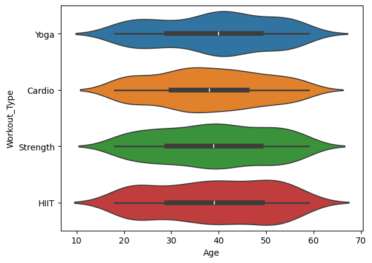

```python
sns.violinplot(y='Workout_Type', x='Age', data=gym, hue='Workout_Type')
```

## Workout type względem doświadczenia - dane bez imputacji

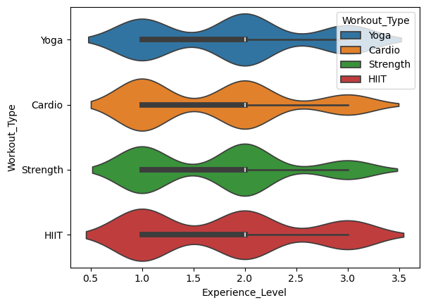

```python
sns.violinplot(y='Workout_Type', x='Experience_Level', data=gym_org, hue='Workout_Type')
```

## Workout type względem doświadczenia - dane po imputacji

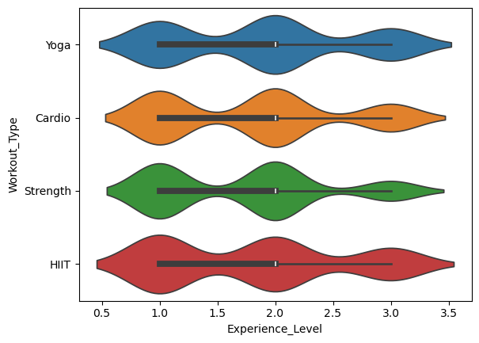

```python
sns.violinplot(y='Workout_Type', x='Experience_Level', data=gym, hue='Workout_Type')
```

```python
skim(gym)
```

```
╭──────────────────────────────────────────────── skimpy summary ─────────────────────────────────────────────────╮
│          Data Summary                Data Types                                                                 │
│ ┏━━━━━━━━━━━━━━━━━━━┳━━━━━━━━┓ ┏━━━━━━━━━━━━━┳━━━━━━━┓                                                          │
│ ┃ Dataframe         ┃ Values ┃ ┃ Column Type ┃ Count ┃                                                          │
│ ┡━━━━━━━━━━━━━━━━━━━╇━━━━━━━━┩ ┡━━━━━━━━━━━━━╇━━━━━━━┩                                                          │
│ │ Number of rows    │ 973    │ │ float64     │ 8     │                                                          │
│ │ Number of columns │ 17     │ │ int64       │ 8     │                                                          │
│ └───────────────────┴────────┘ │ string      │ 1     │                                                          │
│                                └─────────────┴───────┘                                                          │
│                                                     number                                                      │
│ ┏━━━━━━━━━━━━━━━━━━━━━━━━┳━━━━━┳━━━━━━━┳━━━━━━━━━┳━━━━━━━━━┳━━━━━━━━┳━━━━━━━┳━━━━━━━┳━━━━━━━┳━━━━━━━┳━━━━━━━━┓  │
│ ┃ column                 ┃ NA  ┃ NA %  ┃ mean    ┃ sd      ┃ p0     ┃ p25   ┃ p50   ┃ p75   ┃ p100  ┃ hist   ┃  │
│ ┡━━━━━━━━━━━━━━━━━━━━━━━━╇━━━━━╇━━━━━━━╇━━━━━━━━━╇━━━━━━━━━╇━━━━━━━━╇━━━━━━━╇━━━━━━━╇━━━━━━━╇━━━━━━━╇━━━━━━━━┩  │
│ │          Age           │   0 │     0 │   38.58 │   11.69 │     18 │    29 │    39 │    49 │    59 │ ▆▅▇█▆▆ │  │
│ │         Gender         │   0 │     0 │  0.5252 │  0.4996 │      0 │     0 │     1 │     1 │     1 │ ▇    █ │  │
│ │      Weight (kg)       │   0 │     0 │   73.85 │   21.21 │     40 │  58.1 │    70 │    86 │ 129.9 │ ▄█▆▃▂▂ │  │
│ │       Height (m)       │   0 │     0 │   1.723 │  0.1277 │    1.5 │  1.62 │  1.71 │   1.8 │     2 │ ▅█▇▇▄▄ │  │
│ │        Max_BPM         │   0 │     0 │   179.9 │   11.53 │    160 │   170 │   180 │   190 │   199 │ ▇▇█▇██ │  │
│ │        Avg_BPM         │   0 │     0 │   143.8 │   14.35 │    120 │   131 │   143 │   156 │   169 │ ██▇▆▇▇ │  │
│ │      Resting_BPM       │   0 │     0 │   62.22 │   7.327 │     50 │    56 │    62 │    68 │    74 │ ▆▅▆▆▇█ │  │
│ │    Session_Duration    │   0 │     0 │   1.256 │   0.343 │    0.5 │  1.04 │  1.26 │  1.46 │     2 │ ▂▃▇█▂▃ │  │
│ │        (hours)         │     │       │         │         │        │       │       │       │       │        │  │
│ │    Calories_Burned     │   0 │     0 │   905.4 │   272.6 │    303 │   720 │   893 │  1076 │  1783 │ ▂▆█▄▂  │  │
│ │     Fat_Percentage     │   0 │     0 │   24.98 │   6.259 │     10 │  21.3 │  26.2 │  29.3 │    35 │ ▂▂▄▆█▅ │  │
│ │ Water_Intake (liters)  │   0 │     0 │   2.627 │  0.6002 │    1.5 │   2.2 │   2.6 │   3.1 │   3.7 │ ▄▆▅█▃▇ │  │
│ │   Workout_Frequency    │   0 │     0 │   3.322 │   0.913 │      2 │     3 │     3 │     4 │     5 │ ▄ █ ▇▂ │  │
│ │      (days/week)       │     │       │         │         │        │       │       │       │       │        │  │
│ │    Experience_Level    │   0 │     0 │    1.81 │  0.7397 │      1 │     1 │     2 │     2 │     3 │ ▇  █ ▄ │  │
│ │          BMI           │   0 │     0 │   24.91 │   6.661 │  12.32 │ 20.11 │ 24.16 │ 28.56 │ 49.84 │ ▄█▇▂▁  │  │
│ │       Burn_Rate        │   0 │     0 │   720.4 │   86.94 │  539.9 │ 655.6 │ 715.3 │ 781.9 │ 929.5 │ ▃▇█▇▄▂ │  │
│ │       BPM_Delta        │   0 │     0 │   117.7 │   13.43 │     86 │   108 │   118 │   128 │   149 │ ▂▅██▆▂ │  │
│ └────────────────────────┴─────┴───────┴─────────┴─────────┴────────┴───────┴───────┴───────┴───────┴────────┘  │
│                                                     string                                                      │
│ ┏━━━━━━━━━━━━━━┳━━━━┳━━━━━━┳━━━━━━━━━━┳━━━━━━━━━━┳━━━━━━━━┳━━━━━━┳━━━━━━━━━━━━━━┳━━━━━━━━━━━━━━┳━━━━━━━━━━━━━┓  │
│ ┃              ┃    ┃      ┃          ┃          ┃        ┃      ┃ chars per    ┃ words per    ┃             ┃  │
│ ┃ column       ┃ NA ┃ NA % ┃ shortest ┃ longest  ┃ min    ┃ max  ┃ row          ┃ row          ┃ total words ┃  │
│ ┡━━━━━━━━━━━━━━╇━━━━╇━━━━━━╇━━━━━━━━━━╇━━━━━━━━━━╇━━━━━━━━╇━━━━━━╇━━━━━━━━━━━━━━╇━━━━━━━━━━━━━━╇━━━━━━━━━━━━━┩  │
│ │ Workout_Type │  0 │    0 │   Yoga   │ Strength │ Cardio │ Yoga │         5.78 │            1 │         973 │  │
│ └──────────────┴────┴──────┴──────────┴──────────┴────────┴──────┴──────────────┴──────────────┴─────────────┘  │
╰────────────────────────────────────────────────────── End ──────────────────────────────────────────────────────╯
```